# SVM

enes altun

9/5/2021

I will try to predict PAIN which is a very subjective term in the med and psychology with variables that I think “maybe” relevant. You can access data and my kaggle code from here:

[Data](https://www.kaggle.com/enesaltun/this-data-is-pain-svm-r?select=data.csv)

```r
library(tidyverse)
df <- read_delim("SVMdata.csv",";", escape_double = FALSE, trim_ws = TRUE)
```

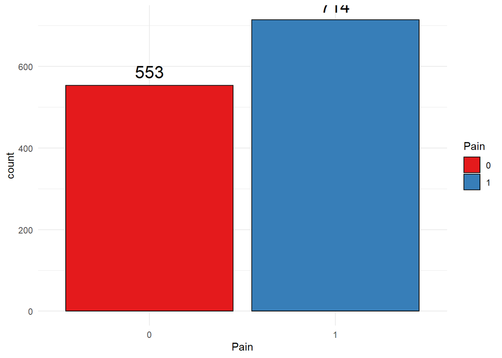

```r
t <- table(df$Pain)
t <- as.data.frame(t)
colnames(t) <- c("Pain","count")
ggplot(t, aes(x=Pain, y=count, fill=Pain)) +
geom_bar(stat="identity", color="black") +
theme_minimal() +
geom_text(aes(label=count), vjust=-0.6, size=6) +
scale_fill_brewer(palette="Set1")
```

Another painful part of this dataset is missing values. First, I would like to look at the total missing values for each column.

```r
names(df)
```

```
##  [1] "Group"                    "Sex"
##  [3] "Age"                      "Patients number per hour"
##  [5] "Arrival mode"             "Injury"
##  [7] "Chief_complain"           "Mental"
##  [9] "Pain"                     "NRS_pain"
## [11] "SBP"                      "DBP"
## [13] "HR"                       "RR"
## [15] "BT"                       "Saturation"
## [17] "KTAS_RN"                  "Diagnosis in ED"
## [19] "Disposition"              "KTAS_expert"
## [21] "Error_group"              "Length of stay_min"
## [23] "KTAS duration_min"        "mistriage"
```

```r
apply(is.na(df), 2, sum)
```

```
##                    Group                      Sex                      Age
##                        0                        0                        0
## Patients number per hour             Arrival mode                   Injury
##                        0                        0                        0
##           Chief_complain                   Mental                     Pain
##                        0                        0                        0
##                 NRS_pain                      SBP                      DBP
##                        0                        0                        0
##                       HR                       RR                       BT
##                        0                        0                        0
##               Saturation                  KTAS_RN          Diagnosis in ED
##                      688                        0                        2
##              Disposition              KTAS_expert              Error_group
##                        0                        0                        0
##       Length of stay_min        KTAS duration_min                mistriage
##                        0                        0                        0
```

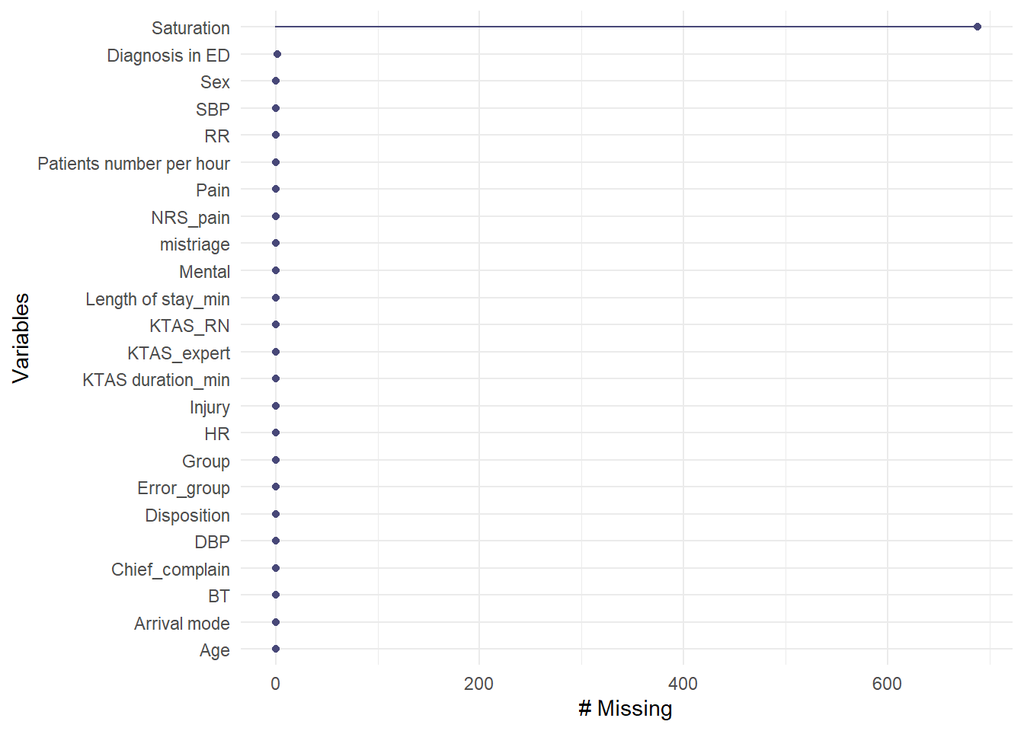

```r
# Plot missing values.
library(naniar)
gg_miss_var(df)
```

This is obivious there are plenty of missing variables in the Saturation. But the more weird thing is in the data, there are some values called “??”. I seen it when I convert the values that I am interested in to numeric.

The simputation package in R (van der Loo, 2019) implements a variety of imputation strategies, such as group-wise median imputation, linear regression etc… The following code uses the method to impute the missing values in the Saturation column using linear regression.

```r
library(simputation)
df$Saturation<-as.numeric(df$Saturation)
df[11:15] <- sapply(df[11:15],as.numeric)
# This part is purely improvisational. There are too many missings in this column and I'm not a fan of the mean imputation if there are many.
imp_df <- impute_lm(df[,-c(1)],Saturation~Age+DBP+SBP+HR+RR+BT)
```

```r
library(imputeTS)
imp_df<-na_mean(imp_df)
#sanity check
apply(is.na(imp_df), 2, sum)
```

```
##                      Sex                      Age Patients number per hour
##                        0                        0                        0
##             Arrival mode                   Injury           Chief_complain
##                        0                        0                        0
##                   Mental                     Pain                 NRS_pain
##                        0                        0                        0
##                      SBP                      DBP                       HR
##                        0                        0                        0
##                       RR                       BT               Saturation
##                        0                        0                        0
##                  KTAS_RN          Diagnosis in ED              Disposition
##                        0                        2                        0
##              KTAS_expert              Error_group       Length of stay_min
##                        0                        0                        0
##        KTAS duration_min                mistriage
##                        0                        0
```

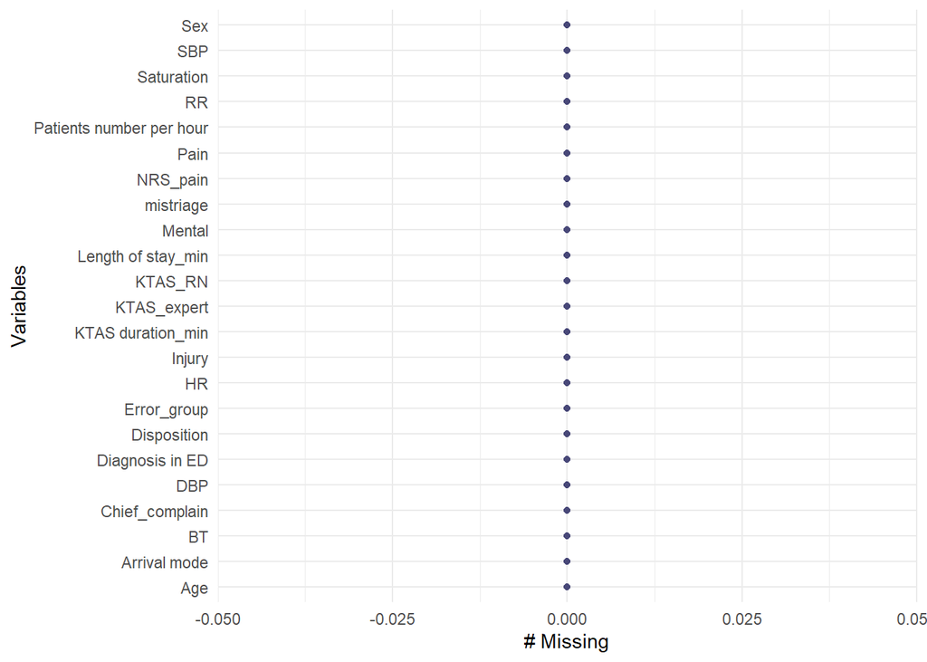

```r
imp_df<-na.omit(imp_df)
gg_miss_var(imp_df)
```

One Hot Encoding for Chief_complain

```r
imp_df<-imp_df %>% mutate(value = 1)  %>% spread(Chief_complain, value,  fill = 0 )
```

```r
# In Chief_complain there were values called "??". Selecting variables that I am interested in:
norm<-imp_df%>%select(c(1,2,10:15,32:439))
norm
```

```
## # A tibble: 1,265 x 416
##      Sex   Age   DBP    HR    RR    BT Saturation KTAS_RN `abd pain`
##    <dbl> <dbl> <dbl> <dbl> <dbl> <dbl>      <dbl>   <dbl>      <dbl>
##  1     2    71   100    84    18  36.6      100         2          0
##  2     1    56    75    60    20  36.5       97.5       4          0
##  3     1    68    80   102    20  36.6       98         4          0
##  4     2    71    94    88    20  36.5       96.8       4          0
##  5     2    58    67    93    18  36.5       98.4       4          0
##  6     1    54    90    94    20  38.1       98         3          0
##  7     2    49    70    70    20  36.2       98         2          0
##  8     2    78    86    80    20  36         97.2       2          0
##  9     2    32    75    91    20  36.6       98.6       4          0
## 10     1    38    80    80    20  36.3       97         4          0
## # ... with 1,255 more rows, and 407 more variables: abd. Distension <dbl>,
## #   Abd. pain <dbl>, abdomen discomfort <dbl>, abdomen distension <dbl>,
## #   abdomen pain <dbl>, Abdominal pain (finding) <dbl>,
## #   abdominal pain, LUQ <dbl>, abdominal pain, periumbilical area <dbl>,
## #   abdominal pain, Rt <dbl>, abnormal lab. <dbl>,
## #   Abnormality, Visual Acuity <dbl>, acute delirium <dbl>,
## #   acute dyspnea <dbl>, acute epigastric pain <dbl>, alcohol smell <dbl>, ...
```

SVM Support vector machines (SVMs) offer a direct approach to binary classification (so it’s applicable to only two classes). In the Pain which we are interested in, we have two classes: -the patient has pain (𝑌 = +1) and patients that do not have pain (𝑌 = −1).

```r
normalize <- function(x) {
    return((x - min(x)) / (max(x) - min(x)))
}

norm<-apply(norm,2,normalize)
```

```r
library(caTools)
set.seed(123)
norm<-as.data.frame(norm)
norm$Pain<-as.factor(imp_df$Pain)
sample<-sample.split(norm,SplitRatio = 0.8)
train<-subset(norm,sample==T)
test<-subset(norm,sample==F)
```

```r
library(caret)
set.seed(1854) # for reproducibility
first_churn_svm <- train(
Pain ~ .,
data = train,
method = "svmRadial",
trControl = trainControl(method = "cv", number = 5),
tuneLength = 8
)
```

[output not shown]

[output cut: 28 more lines]

[output not shown]

```r
confusionMatrix(first_churn_svm)
```

```
## Cross-Validated (5 fold) Confusion Matrix
##
## (entries are percentual average cell counts across resamples)
##
##           Reference
## Prediction    0    1
##          0 32.7  8.2
##          1 11.2 47.8
##
##  Accuracy (average) : 0.8056
```

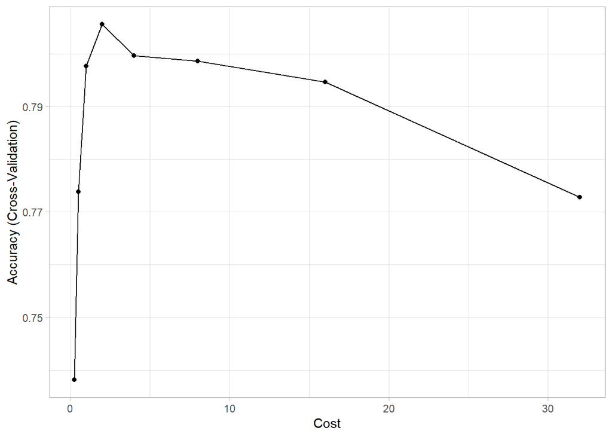

```r
ggplot(first_churn_svm) + theme_light()
```

```r
ctrl <- trainControl(
method = "cv",
number = 15,
classProbs = TRUE,
summaryFunction = twoClassSummary # also needed for AUC/ROC
)
```

```r
levels(train$Pain) <- c("No", "Yes")
```

```r
table(train$Pain)
```

```
##
##  No Yes
## 443 565
```

SVMs classify new data by identifying which side of the decision boundary they fall on; as a result, they do not provide class probabilities automatically. Predicted class probabilities are more useful than predicted class labels in most scenarios.

```r
# Tune an SVM
set.seed(123) # for reproducibility
Pain_svm_auc <- train(
Pain ~ .,
data = train,
method = "svmRadial",
metric = "ROC", # area under ROC curve (AUC)
trControl = ctrl,
tuneLength = 15)
```

[output not shown]

[output cut: 398 more lines]

[output not shown]

Similar to before, we see that smaller values of the cost parameter provide better cross-validated AUC scores on the training data:

```r
Pain_svm_auc$results
```

```
##        sigma       C       ROC      Sens      Spec      ROCSD     SensSD
## 1  0.3753193    0.25 0.8599473 0.7016092 0.8693694 0.05612426 0.07941237
## 2  0.3753193    0.50 0.8751341 0.7244444 0.8568990 0.05172320 0.06818035
## 3  0.3753193    1.00 0.8791329 0.7517241 0.8569464 0.04794389 0.06729925
## 4  0.3753193    2.00 0.8775198 0.7358621 0.8551920 0.04417149 0.06189418
## 5  0.3753193    4.00 0.8709454 0.7223755 0.8480797 0.04884229 0.05431717
## 6  0.3753193    8.00 0.8698582 0.7403831 0.8444286 0.04948701 0.06128537
## 7  0.3753193   16.00 0.8660827 0.7495019 0.8374111 0.05206548 0.05858440
## 8  0.3753193   32.00 0.8527400 0.7311877 0.8128023 0.05191687 0.05749731
## 9  0.3753193   64.00 0.8313656 0.7203065 0.7880512 0.05736820 0.06186439
## 10 0.3753193  128.00 0.8090926 0.6818391 0.7597914 0.05861884 0.06240135
## 11 0.3753193  256.00 0.7912394 0.6368582 0.7385017 0.05922469 0.06971604
## 12 0.3753193  512.00 0.7677672 0.6095785 0.7436226 0.05729409 0.06880340
## 13 0.3753193 1024.00 0.7588243 0.6026820 0.7383120 0.05979422 0.06398500
## 14 0.3753193 2048.00 0.7570174 0.5914943 0.7418682 0.06422436 0.06074393
```

[output cut: 17 more lines]

```r
confusionMatrix(Pain_svm_auc)
```

```
## Cross-Validated (15 fold) Confusion Matrix
##
## (entries are percentual average cell counts across resamples)
##
##           Reference
## Prediction   No  Yes
##        No  33.0  8.0
##        Yes 10.9 48.0
##
##  Accuracy (average) : 0.8105
```

Like many other Machine Learning algorithms, support v.m do not emit any natural measures of feature importance but, we can use the VIP package to get importance results for each variable using the permutation approach

```r
prob_yes <- function(object, newdata) {
predict(object, newdata = newdata, type = "prob")[, "Yes"]
}
```

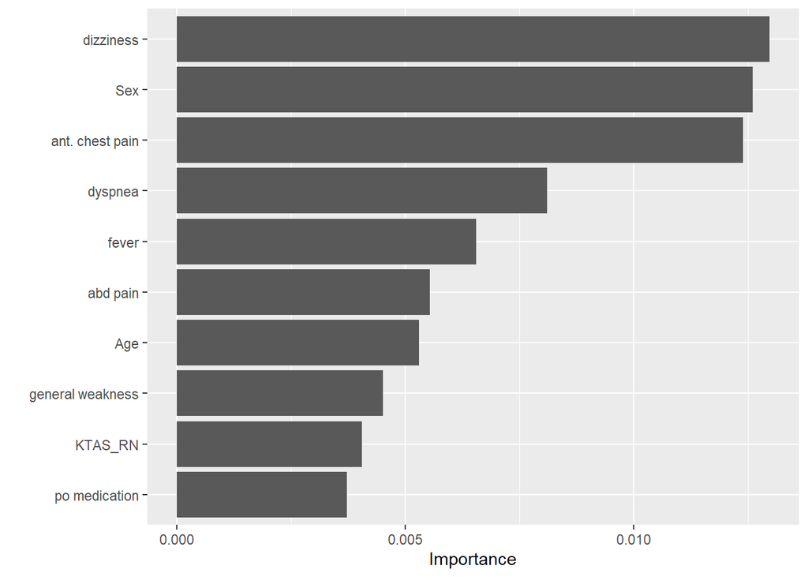

```r
# Variable importance plot
library(vip)
set.seed(2827) # for reproducibility
vip(Pain_svm_auc, method = "permute", nsim = 5, train = train,
target = "Pain", metric = "auc", reference_class = "Yes",
pred_wrapper = prob_yes)
```

The results indicate that sex and dizziness is the most important feature in predicting pain in this model.

```r
# construct PDPs forthe top four features according to the permutation-based variable importance scores
library(pdp)
```

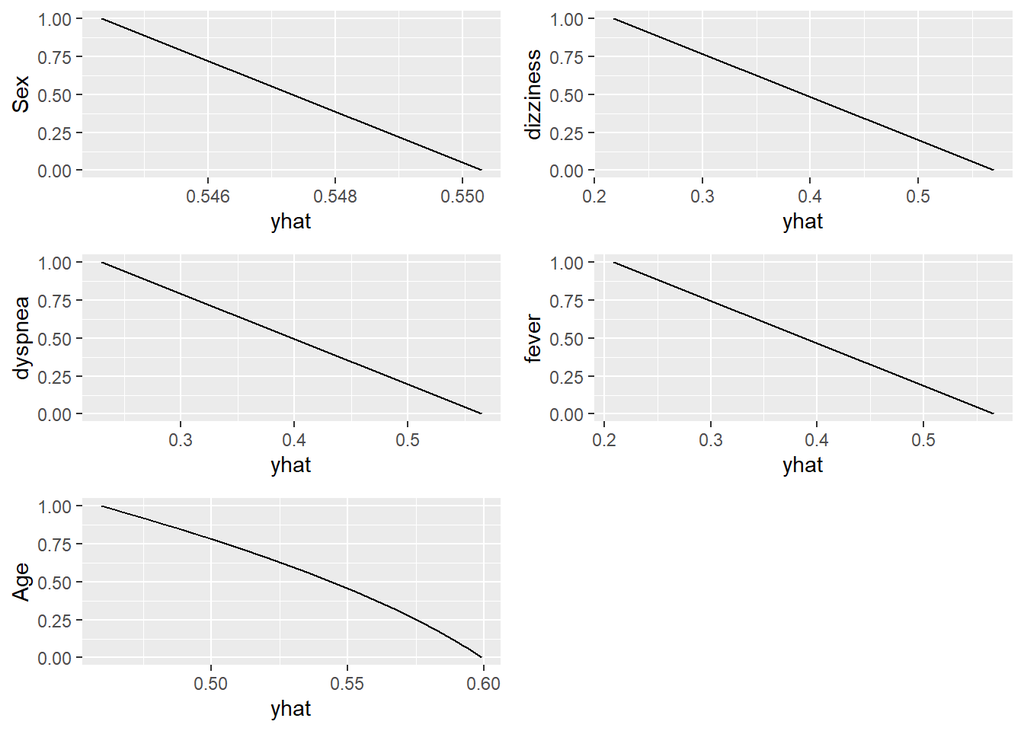

```r
features <- c("Sex", "dizziness",
"dyspnea","fever","Age")
pdps <- lapply(features, function(x) {
partial(Pain_svm_auc, pred.var = x, which.class = 2,
prob = TRUE, plot = TRUE, plot.engine = "ggplot2") +
coord_flip()
})
grid.arrange(grobs = pdps, ncol = 2)
```

```r
levels(test$Pain) <- c("No", "Yes")
y_pred = predict(Pain_svm_auc, test)
```

```r
caret::confusionMatrix(table(y_pred,test$Pain))
```

```
## Confusion Matrix and Statistics
##
##
## y_pred  No Yes
##    No   86  31
##    Yes  23 117
##
##                Accuracy : 0.7899
##                  95% CI : (0.7349, 0.838)
##     No Information Rate : 0.5759
##     P-Value [Acc > NIR] : 3.88e-13
##
##                   Kappa : 0.574
##
##  Mcnemar's Test P-Value : 0.3408
##
##             Sensitivity : 0.7890
##             Specificity : 0.7905
##          Pos Pred Value : 0.7350
##          Neg Pred Value : 0.8357
##              Prevalence : 0.4241
##          Detection Rate : 0.3346
##    Detection Prevalence : 0.4553
##       Balanced Accuracy : 0.7898
##
##        'Positive' Class : No
##
```

%80. SVM is flexible enough to adapt to complex nonlinear decision boundaries. It directly attempts to maximize generalizability accuracy and is robust for outliers. But even with a very low tune length, it’s very slow to train data.